# Отчёт по лабораторной работе №3

Настройка DHCP-сервера Kea и DDNS-интеграции с Bind

Элсаиед Адел

Российский университет дружбы народов, Москва, Россия

2 января 2026

# Цели и задачи работы

## Цель

Приобретение практических навыков установки и конфигурирования DHCP-сервера.

# Выполнение работы

## Установка Kea DHCP

- переход в режим суперпользователя (`sudo -i`)
- установка пакета `kea` через `dnf`
- зависимости установлены автоматически, ошибок не выявлено

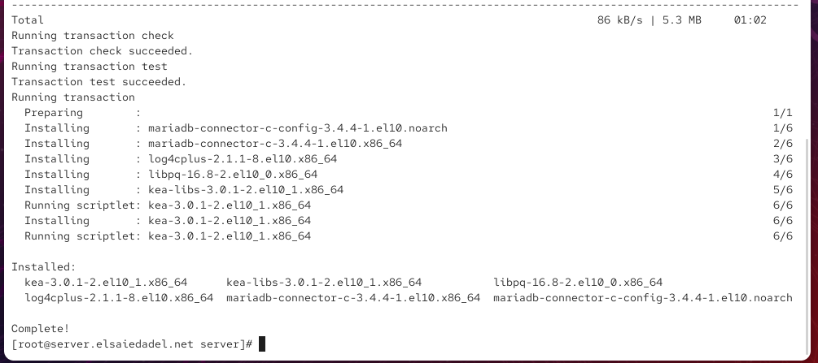

Установка DHCP-сервера Kea

## Настройка DHCP: параметры DNS

- DNS-сервер для клиентов: `192.168.1.1`
- доменное имя: `elsaiedadel.net`
- домен поиска: `elsaiedadel.net`

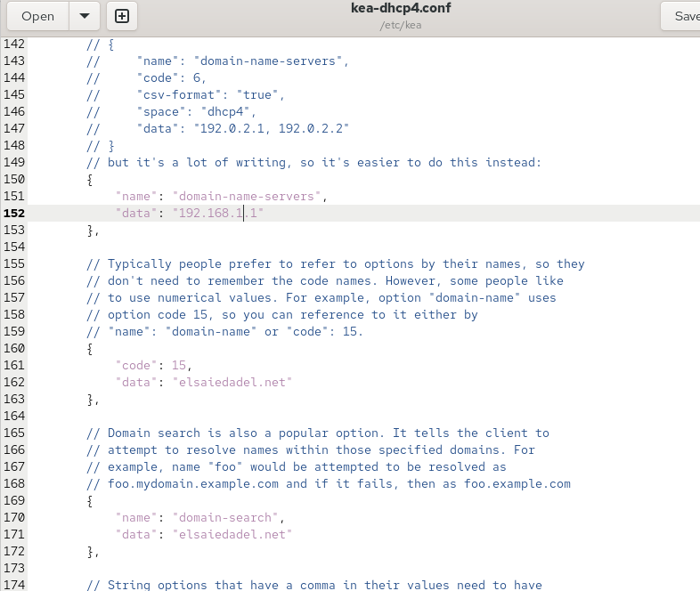

Настройка параметров DNS в kea-dhcp4.conf

## Настройка DHCP: подсеть и пул адресов

- подсеть: `192.168.1.0/24`
- пул: `192.168.1.30 - 192.168.1.199`
- шлюз (routers): `192.168.1.1`

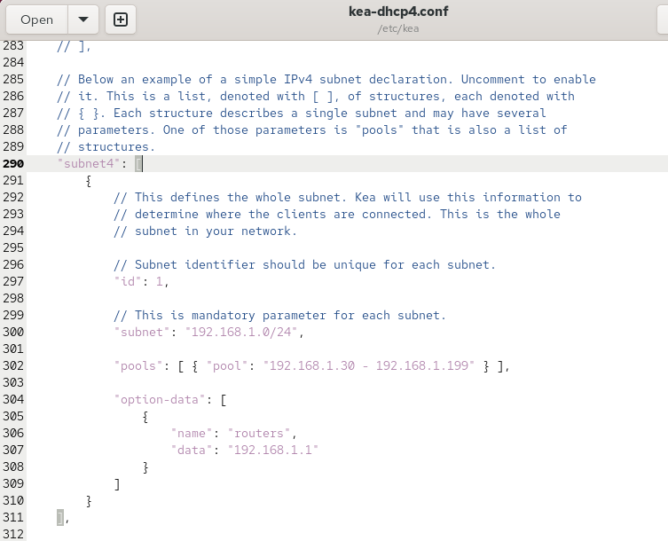

Конфигурация DHCP-подсети

## DNS: добавление записей DHCP-сервера

- прямая зона: `dhcp A 192.168.1.1`

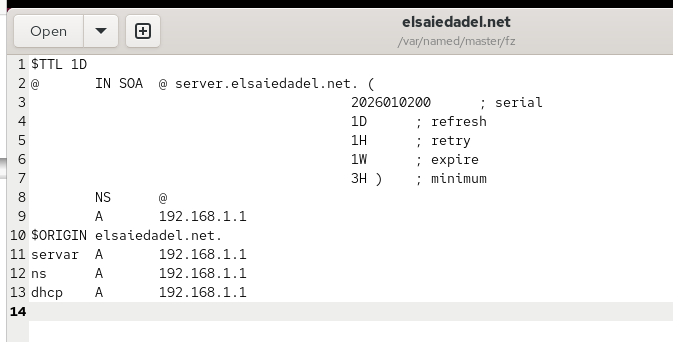

Настройка прямой DNS-зоны

## DNS: добавление записей DHCP-сервера

- обратная зона: `1 PTR dhcp.elsaiedadel.net.`

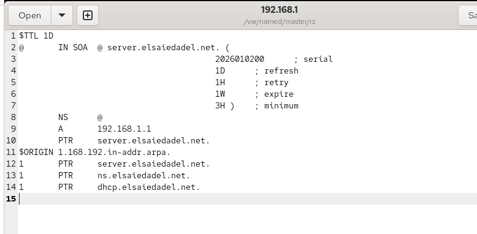

Настройка обратной DNS-зоны

## Проверка разрешения имени DHCP

- перезапуск Bind: `systemctl restart named`
- проверка: `ping dhcp.elsaiedadel.net`
- имя разрешается, потерь пакетов нет

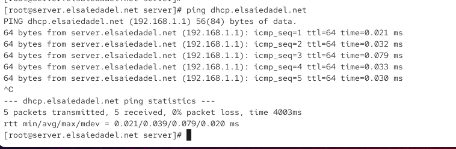

Проверка разрешения имени DHCP-сервера

## Firewall и SELinux, запуск DHCP

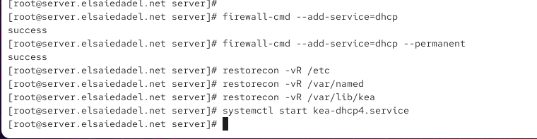

Запуск DHCP-сервера Kea

## Provisioning маршрутизации на client

- шлюз по умолчанию назначается через `eth1`
- для `eth0` отключается default-route (IPv4/IPv6)
- переподнимаются соединения NetworkManager

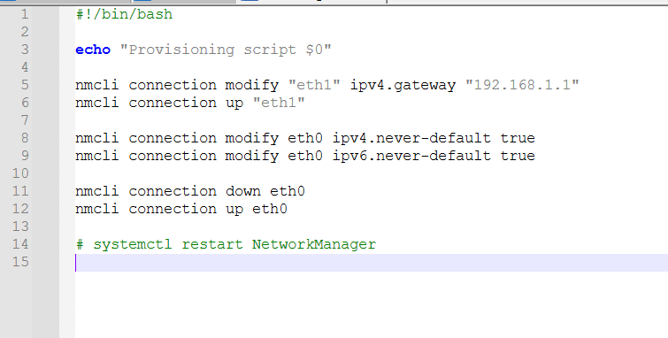

Provisioning-скрипт настройки маршрутизации client

## Получение адреса и ifconfig на client

- `eth1`: получен адрес `192.168.1.30/24`, broadcast `192.168.1.255`
- `eth0`: активен, но не является дефолтным маршрутом
- `lo`: локальная петля `127.0.0.1`

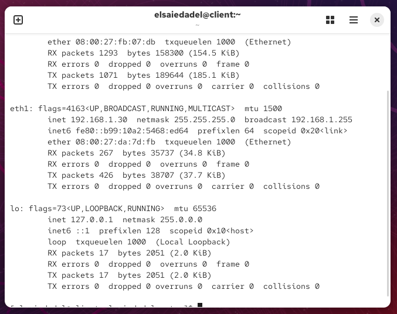

Сетевые интерфейсы виртуальной машины client

## Файл аренд Kea: kea-leases4.csv

- `address` — выданный IP (`192.168.1.30`)
- `hwaddr` — MAC-адрес клиента
- `client_id` — идентификатор клиента (если используется)
- `valid_lifetime` — длительность аренды
- `expire` — время истечения аренды (epoch)
- `subnet_id` — ID подсети (в конфигурации `id: 1`)
- `state` — состояние записи аренды

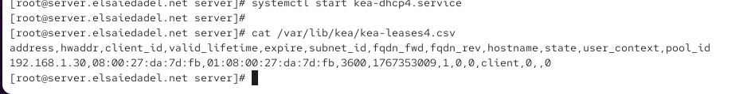

Файл аренды DHCP kea-leases4.csv

## TSIG-ключ для динамических обновлений

- сгенерирован ключ:
  - `tsig-keygen -a HMAC-SHA512 DHCP_UPDATER > /etc/named/keys/dhcp_updater.key`

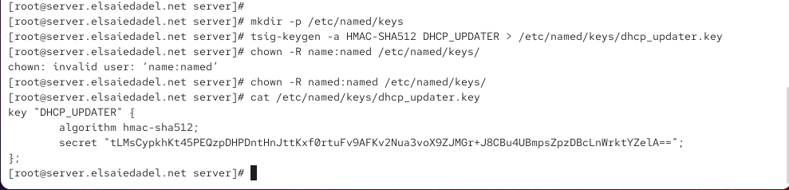

Генерация TSIG-ключа DHCP_UPDATER

## Bind: разрешение обновлений зон (update-policy)

В конфигурации зон включены правила:

- прямая зона `elsaiedadel.net`: разрешить `A` по ключу `DHCP_UPDATER`
- обратная зона `1.168.192.in-addr.arpa`: разрешить `PTR` по ключу `DHCP_UPDATER`

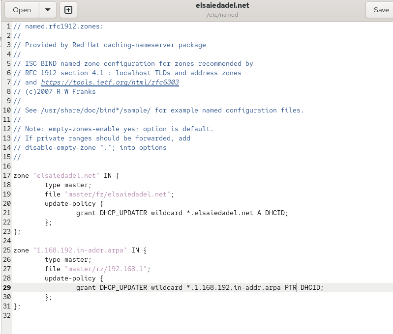

Настройка update-policy для DNS-зон

## Kea: ключ в JSON и конфигурация DHCP-DDNS

1. Создан файл `/etc/kea/tsig-keys.json` (TSIG в формате JSON)
2. Настроен `/etc/kea/kea-dhcp-ddns.conf`:

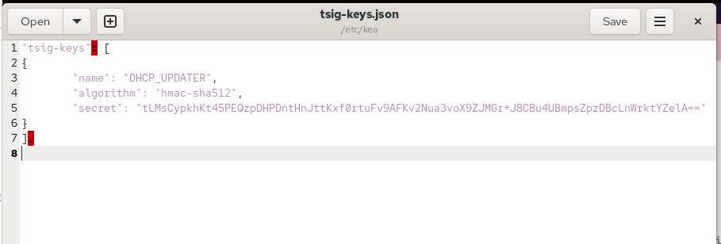

TSIG-ключ в формате JSON для Kea

## Kea: ключ в JSON и конфигурация DHCP-DDNS

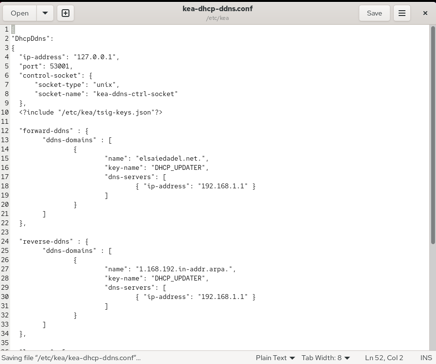

Конфигурация DHCP-DDNS в Kea

## Запуск kea-dhcp-ddns и включение обновлений в DHCPv4

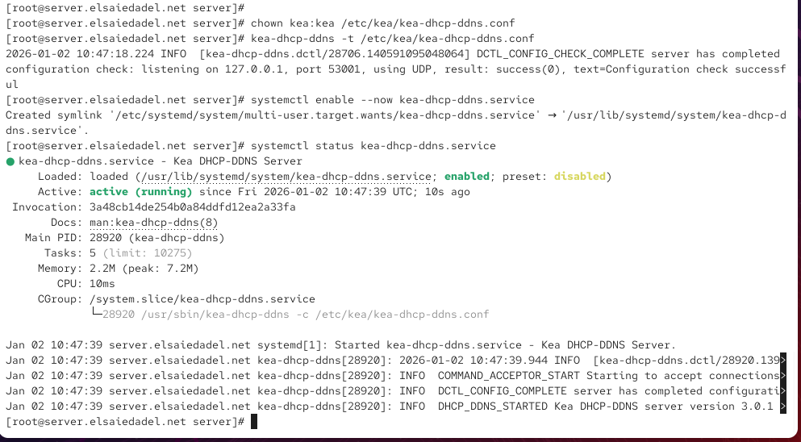

Состояние службы kea-dhcp-ddns

## Запуск kea-dhcp-ddns и включение обновлений в DHCPv4

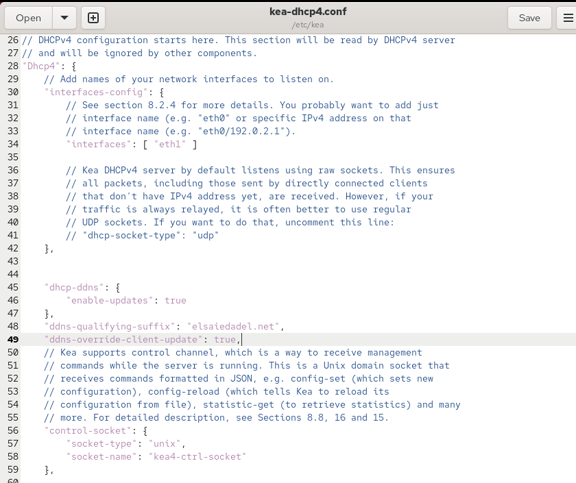

Настройка DDNS в kea-dhcp4.conf

## Запуск kea-dhcp-ddns и включение обновлений в DHCPv4

- перезапуск DHCP

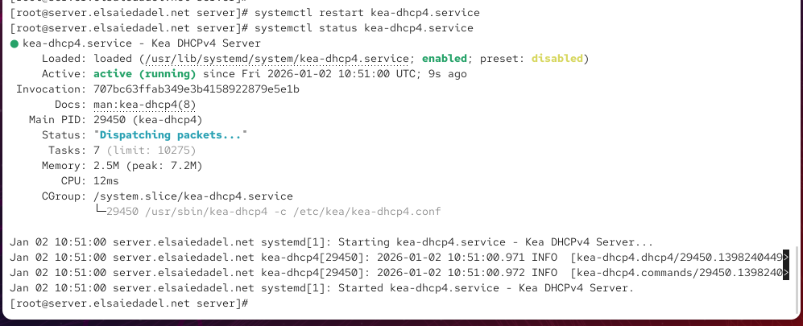

Состояние службы kea-dhcp4

## Проверка: запись клиента появилась в DNS (dig)

Ключевые признаки корректной работы:

- `status: NOERROR` — запись найдена
- `aa` — ответ авторитетный
- в ANSWER: `A 192.168.1.30` — имя сопоставлено выданному адресу

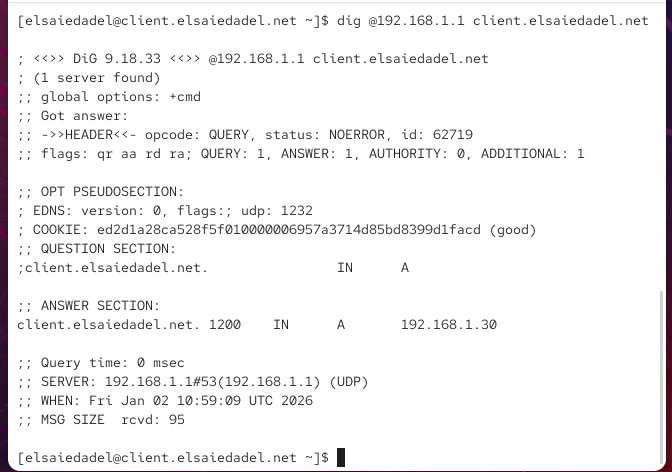

Проверка DNS-записи клиента с помощью dig

## Сохранение конфигураций и скрипт dhcp.sh

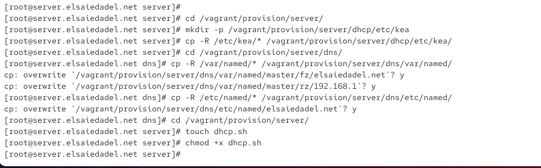

Копирование конфигурации DNS и DHCP

## Сохранение конфигураций и скрипт dhcp.sh

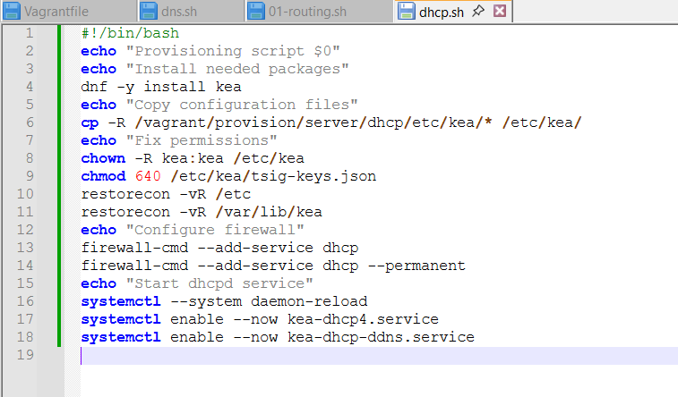

Provisioning-скрипт dhcp.sh

# Выводы

## Итог

- Настроен Kea DHCPv4: выдача адресов и сетевых параметров
- Проанализирована работа DHCP на клиенте (маршрутизация, ifconfig, leases)
- Реализована интеграция DHCP и Bind через DDNS (TSIG + update-policy)
- Подтверждено автоматическое создание DNS-записи клиента (dig)
- Выполнена автоматизация действий через provisioning-скрипты Vagrant